# Plots and Tables - Master thesis

Manon Felix

2021-05-28 13:57:32

# Functions

`Whittle` is a function based on the source code of the `longmemo` package, I have simply adapted the notation and inputs to be clearer.

Function `Whittle = function(theta, phi, H, p, q, y)` where:

- $theta$ is a vector of length $p$.
- $phi$ is a vector of length $q$.
- $H$ self-similarity parameter (recap: ARIMA(0,d,0) process d = H − 1/2)
- $p$ , $q$ are optional integers specifying the AR and MA orders of the FARIMA model
- $y$ is a numeric vector representing a time series

The `Wasserstein` function computes the estimated parameter of a process by minimising the wasserstein distance between the standardized perdiodogram ordinates and a vector, say $t$, of random variables following an Exponential(1) distribution.

Function `Wasserstein = function(theta, phi, H, p, q, y, theoritical, weighted = FALSE, sinkhorn = FALSE, lambda = 1, cdf = FALSE, mean = FALSE, k = 1)` where

- $theta$ is a vector of length $p$.
- $phi$ is a vector of length $q$.
- $H$ self-similarity parameter (recap: ARIMA(0,d,0) process d = H − 1/2)
- $p$ , $q$ are optional integers specifying the AR and MA orders of the FARIMA model
- $y$ is a numeric vector representing a time series
- $theoritical$ is a vector of length $((n-1)/2)$ of Exponential(1) random variables (use `rexp(((n-1)/2), rate = 1)`).
- $weighted$ specifies whether weights for the std.per.ord should be used when calculating the Wasserstein distance. The weights chosen are

$$w_j = \frac{I(\lambda_j)}{f(\lambda_j; \theta)} / \sum \frac{I(\lambda_j)}{f(\lambda_j; \theta)} \textit{ for a fixed } \theta$$

- $sinkhorn$ specifies whether instead of the Wasserstein distance the Sinkhorn distance should be calculated with the lambda corresponding to the next input.
- $cdf$ specifies if the true cumulative distribution function must be used to compute the Wasserstein distance.
- $mean$ compute the mean of the minimum wasserstein estimator with corresponding $k$ vectors $Z_j$

Note: the packages use for the [Wasserstein](https://cran.r-project.org/web/packages/transport/transport.pdf) and the [Sinkhorn](https://cran.r-project.org/web/packages/Barycenter/Barycenter.pdf) are respectively `transport` and `Barycenter`.

# Packages

```r
library(tidyverse)
library(ggplot2)
library(ggfortify)
library(gridExtra)
library(ggpubr)
library(patchwork)
library(pracma)
library(T4transport)
library(Barycenter)

## Load functions
source("/Users/manonfelix/OneDrive/Master thesis/Redaction/WH_WD_SH_functions.R")
```

# Estimation methods

## Minimum Wasserstein Estimators

### Figure 1

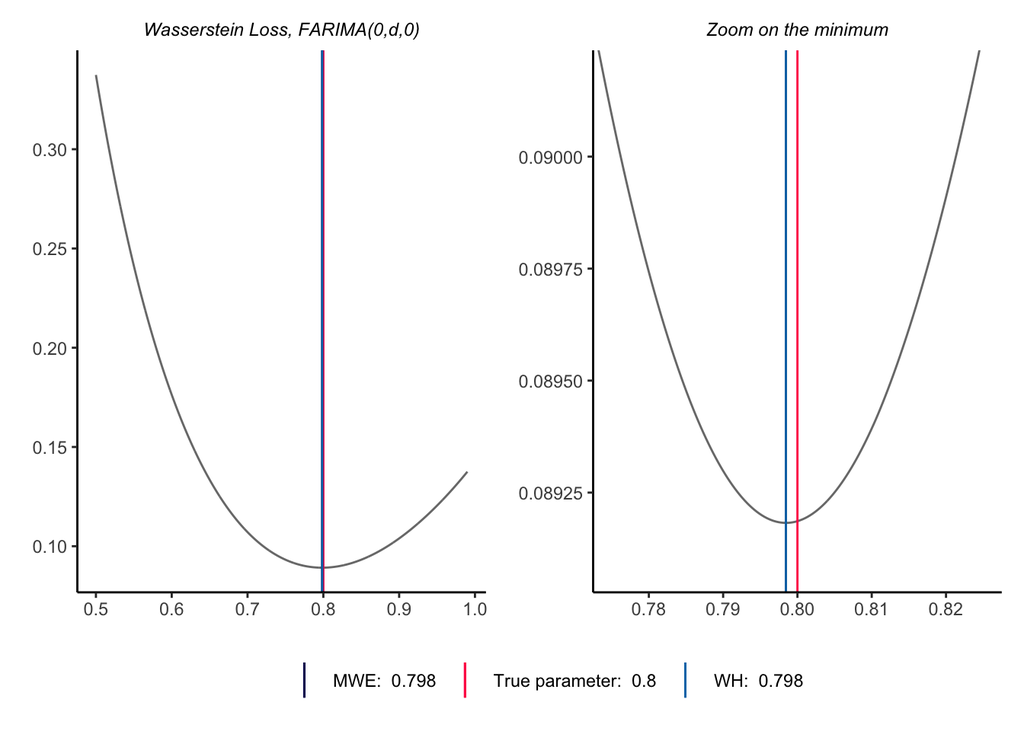

```r
set.seed(8963)
### Simulate time series
p = 1
n = 3001
H = 0.8
y = longmemo::simARMA0(n, H = H)

## Fundamental frequencies
m = length(y); mhalfm <- (m-1) %/% 2L
x <- 2*pi/m * (1:mhalfm)

### Compute the periodogram ordinates
per = (Mod(fft(y))^2/(2*pi*m)) [1:(m %/% 2 + 1)]
yper = periodogr.x = per[2:((m+1) %/% 2)]

### Parameter values
par = seq(0.5, 0.99, length.out = length(x))
m = length(par)

### Initialize matrices and vector(s)
per_ord_std = matrix(nrow=length(x), ncol=length(par));
spec = matrix(nrow=length(x), ncol=length(par))
px <- outer(x, 1:p)
WD_2 = rep(NA, m)
WH_2 = rep(NA, m)

### Compute the standardized periodogram ordinates
for (i in 1:length(x)){
  for (j in 1:length(par)){
    spec[i,j] = sqrt(2 - 2*cos(px[i]))^(1-2*par[j])
    per_ord_std[i,j]  = 2*pi * yper[i] / spec[i,j]
  }}

### Generate the random vector of Exponential(1) variables
set.seed(8764)
t = rexp(1500,rate  = 1)

### Compute the 1-Wasserstein distance between the SPOs and t
p = 1
for (i in 1:length(per_ord_std[,i])){
  WD_2[i] = (mean(abs(sort(t) - sort(per_ord_std[,i]))^p)^(1/p))
  WH_2[i] = sum(per_ord_std[,i])
}

### Plot the Wasserstein loss function
p3 = ggplot(data = NULL, aes(x = par, y = WD_2)) + geom_line(alpha = 0.6) + theme_classic() +
  theme(plot.title = element_text(color = "black", size = 9, face = "italic", hjust = 0.5)) +
  labs(y = expression(""), x = expression(""),
       title = paste("Wasserstein Loss, FARIMA(0,d,0)")) +
  geom_vline(aes(xintercept = H, colour = paste("True parameter: ", H)), show.legend = T) +
  geom_vline(aes(xintercept = par[which.min(WD_2)], colour = paste("MWE: ", round(par[which.min(WD_2)], digits = 3))), show.legend = T) +
  geom_vline(aes(xintercept = par[which.min(WH_2)], colour = paste("WH: ", round(par[which.min(WH_2)], digits = 3))), show.legend = T) +
  scale_colour_manual(values = c("#03045E", "#FF0A54", "#0077B6"))

### Zoom

p4 = ggplot(data = NULL, aes(x = par, y = WD_2)) + geom_line(alpha = 0.6) + theme_classic() +
  theme(plot.title = element_text(color = "black", size = 9, face = "italic", hjust = 0.5)) +
  labs(y = expression(""), x = expression(""),
       title = paste("Zoom on the minimum")) +
  geom_vline(aes(xintercept = H, colour = paste("True parameter: ", H)), show.legend = T) +
  geom_vline(aes(xintercept = par[which.min(WD_2)], colour = paste("MWE: ", round(par[which.min(WD_2)], digits = 3))), show.legend = T) +
  geom_vline(aes(xintercept = par[which.min(WH_2)], colour = paste("WH: ", round(par[which.min(WH_2)], digits = 3))), show.legend = T) +
  scale_colour_manual(values = c("#03045E", "#FF0A54", "#0077B6")) +
   coord_cartesian(xlim=c(0.775, 0.825), ylim=c((min(WD_2)-0.0001), (min(WD_2)+0.001)))



combined <- p3 + p4 & theme(legend.title = element_blank(), legend.position = 'bottom')
combined + plot_layout(guides = "collect")
```

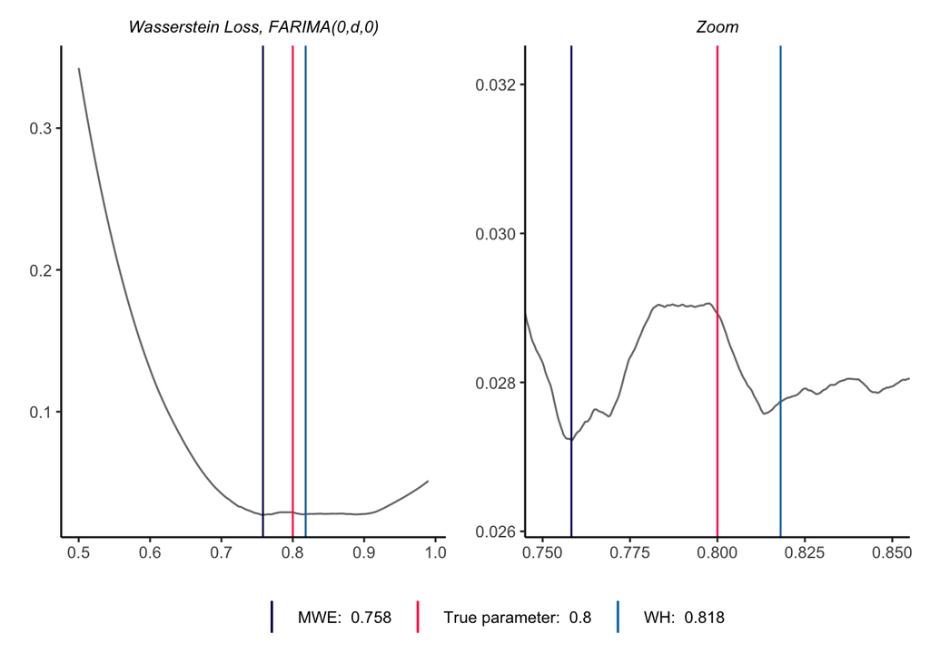

```r
set.seed(8963)
### Simulate time series
p = 1
n = 3001
H = 0.8
y = longmemo::simARMA0(n, H = H)

## Fundamental frequencies
m = length(y); mhalfm <- (m-1) %/% 2L
x <- 2*pi/m * (1:mhalfm)

### Compute the periodogram ordinates
per = (Mod(fft(y))^2/(2*pi*m)) [1:(m %/% 2 + 1)]
yper = periodogr.x = per[2:((m+1) %/% 2)]

### Parameter values
par = seq(0.5, 0.99, length.out = length(x))
m = length(par)

### Initialize matrices and vector(s)
per_ord_std = matrix(nrow=length(x), ncol=length(par));
spec = matrix(nrow=length(x), ncol=length(par))
px <- outer(x, 1:p)
WD_2 = rep(NA, m)
WH_2 = rep(NA, m)

### Compute the standardized periodogram ordinates
for (i in 1:length(x)){
  for (j in 1:length(par)){
    spec[i,j] = sqrt(2 - 2*cos(px[i]))^(1-2*par[j])
    per_ord_std[i,j]  = 2*pi * yper[i] / spec[i,j]
  }}

### Generate the random vector of Exponential(1) variables
set.seed(8764)
t = rexp(1500,rate  = 1)

### Compute the 1-Wasserstein distance between the SPOs and t
p = 1
for (i in 1:length(per_ord_std[,i])){
  WD_2[i] = (mean(abs(sort(t) - sort(per_ord_std[,i]))^p)^(1/p))
  WH_2[i] = sum(per_ord_std[,i])
}

### Plot the Wasserstein loss function
p3 = ggplot(data = NULL, aes(x = par, y = WD_2)) + geom_line(alpha = 0.6) + theme_classic() +
  theme(plot.title = element_text(color = "black", size = 9, face = "italic", hjust = 0.5)) +
  labs(y = expression(""), x = expression(""),
       title = paste("Wasserstein Loss, FARIMA(0,d,0)")) +
  geom_vline(aes(xintercept = H, colour = paste("True parameter: ", H)), show.legend = T) +
  geom_vline(aes(xintercept = par[which.min(WD_2)], colour = paste("MWE: ", round(par[which.min(WD_2)], digits = 3))), show.legend = T) +
  geom_vline(aes(xintercept = par[which.min(WH_2)], colour = paste("WH: ", round(par[which.min(WH_2)], digits = 3))), show.legend = T) +
  scale_colour_manual(values = c("#03045E", "#FF0A54", "#0077B6"))

### Zoom

p4 = ggplot(data = NULL, aes(x = par, y = WD_2)) + geom_line(alpha = 0.6) + theme_classic() +
  theme(plot.title = element_text(color = "black", size = 9, face = "italic", hjust = 0.5)) +
  labs(y = expression(""), x = expression(""),
       title = paste("Zoom on the minimum")) +
  geom_vline(aes(xintercept = H, colour = paste("True parameter: ", H)), show.legend = T) +
  geom_vline(aes(xintercept = par[which.min(WD_2)], colour = paste("MWE: ", round(par[which.min(WD_2)], digits = 3))), show.legend = T) +
  geom_vline(aes(xintercept = par[which.min(WH_2)], colour = paste("WH: ", round(par[which.min(WH_2)], digits = 3))), show.legend = T) +
  scale_colour_manual(values = c("#03045E", "#FF0A54", "#0077B6")) +
   coord_cartesian(xlim=c(0.775, 0.825), ylim=c((min(WD_2)-0.0001), (min(WD_2)+0.001)))

set.seed(3459)
### Simulate time series
n = 3001
H = 0.8
y = longmemo::simARMA0(n, H = H)

## Fundamental frequencies
m = length(y); mhalfm <- (m-1) %/% 2L
x <- 2*pi/m * (1:mhalfm)

### Compute the periodogram ordinates
per = (Mod(fft(y))^2/(2*pi*m)) [1:(m %/% 2 + 1)]
yper = periodogr.x = per[2:((m+1) %/% 2)]

### Parameter values
par = seq(0.5, 0.99, length.out = length(x))
m = length(par)

### Initialize matrices and vector(s)
per_ord_std = matrix(nrow=length(x), ncol=length(par));
spec = matrix(nrow=length(x), ncol=length(par))
px <- outer(x, 1:p)
WD_2 = numeric(m)
WH_2 = numeric(m)

### Compute the standardized periodogram ordinates
for (i in 1:length(x)){
  for (j in 1:length(par)){
    spec[i,j] = sqrt(2 - 2*cos(px[i]))^(1-2*par[j])
    per_ord_std[i,j]  = 2*pi * yper[i] / spec[i,j]
  }}

### Generate the random vector of Exponential(1) variables
set.seed(8764)
t = rexp(1500,rate  = 1)

### Compute the 1-Wasserstein distance between the SPOs and t
p = 1
for (i in 1:length(per_ord_std[,i])){
  WD_2[i] = (mean(abs(sort(t) - sort(per_ord_std[,i]))^p)^(1/p))
  WH_2[i] = sum(per_ord_std[,i])
}

### Plot the Wasserstein loss function
p3 = ggplot(data = NULL, aes(x = par, y = WD_2)) + geom_line(alpha = 0.6) + theme_classic() +
  theme(plot.title = element_text(color = "black", size = 9, face = "italic", hjust = 0.5)) +
  labs(y = expression(""), x = expression(""),
       title = paste("Wasserstein Loss, FARIMA(0,d,0)")) +
  geom_vline(aes(xintercept = H, colour = paste("True parameter: ", H)), show.legend = T) +
  geom_vline(aes(xintercept = par[which.min(WD_2)], colour = paste("MWE: ", round(par[which.min(WD_2)], digits = 3))), show.legend = T) +
  geom_vline(aes(xintercept = par[which.min(WH_2)], colour = paste("WH: ", round(par[which.min(WH_2)], digits = 3))), show.legend = T) +
  scale_colour_manual(values = c("#03045E", "#FF0A54", "#0077B6"))

### Zoom

p4 = ggplot(data = NULL, aes(x = par, y = WD_2)) + geom_line(alpha = 0.6) + theme_classic() +
  theme(plot.title = element_text(color = "black", size = 9, face = "italic", hjust = 0.5)) +
  labs(y = expression(""), x = expression(""),
       title = paste("Zoom")) +
  geom_vline(aes(xintercept = H, colour = paste("True parameter: ", H)), show.legend = T) +
  geom_vline(aes(xintercept = par[which.min(WD_2)], colour = paste("MWE: ", round(par[which.min(WD_2)], digits = 3))), show.legend = T) +
  geom_vline(aes(xintercept = par[which.min(WH_2)], colour = paste("WH: ", round(par[which.min(WH_2)], digits = 3))), show.legend = T) +
  scale_colour_manual(values = c("#03045E", "#FF0A54", "#0077B6")) +
   coord_cartesian(xlim=c(0.75, 0.85), ylim=c((min(WD_2)-0.001), (min(WD_2)+0.005)))


combined <- p3 + p4 & theme(legend.title = element_blank(), legend.position = 'bottom')
combined + plot_layout(guides = "collect")
```

### Figure 2

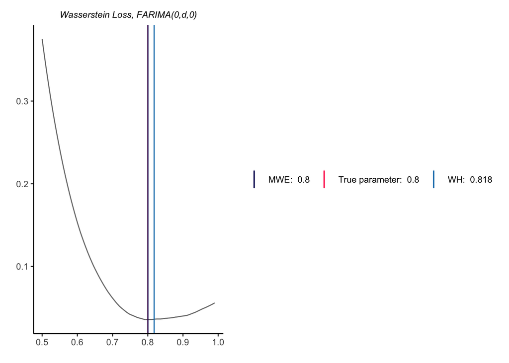

Wasserstein loss function of the FARIMA(0,d,0) process (bottom one) of Figure 1 computed with another random vector.

```r
set.seed(3459)
### Simulate time series
n = 3001
H = 0.8
y = longmemo::simARMA0(n, H = H)

## Fundamental frequencies
m = length(y); mhalfm <- (m-1) %/% 2L
x <- 2*pi/m * (1:mhalfm)

### Compute the periodogram ordinates
per = (Mod(fft(y))^2/(2*pi*m)) [1:(m %/% 2 + 1)]
yper = periodogr.x = per[2:((m+1) %/% 2)]

### Parameter values
par = seq(0.5, 0.99, length.out = length(x))
m = length(par)

### Initialize matrices and vector(s)
per_ord_std = matrix(nrow=length(x), ncol=length(par));
spec = matrix(nrow=length(x), ncol=length(par))
px <- outer(x, 1:p)
WD = numeric(m)
WH = numeric(m)

### Compute the standardized periodogram ordinates
for (i in 1:length(x)){
  for (j in 1:length(par)){
    spec[i,j] = sqrt(2 - 2*cos(px[i]))^(1-2*par[j])
    per_ord_std[i,j]  = 2*pi * yper[i] / spec[i,j]
  }}

### Generate the random vector of Exponential(1) variables
set.seed(8764)
t = rexp(1500,rate  = 1)

### Compute the 1-Wasserstein distance between the SPOs and t
p = 1
for (i in 1:length(per_ord_std[,i])){
  WD[i] = (mean(abs(sort(t) - sort(per_ord_std[,i]))^p)^(1/p))
  WH[i] = sum(per_ord_std[,i])
}

### Plot the Wasserstein loss function
p3 = ggplot(data = NULL, aes(x = par, y = WD)) + geom_line(alpha = 0.6) + theme_classic() +
  theme(plot.title = element_text(color = "black", size = 9, face = "italic", hjust = 0.5)) +
  labs(y = expression(""), x = expression(""),
       title = paste("Wasserstein Loss, FARIMA(0,d,0)")) +
  geom_vline(aes(xintercept = H, colour = paste("True parameter: ", H)), show.legend = T) +
  geom_vline(aes(xintercept = par[which.min(WD)], colour = paste("MWE: ", round(par[which.min(WD)], digits = 3))), show.legend = T) +
  geom_vline(aes(xintercept = par[which.min(WH)], colour = paste("WH: ", round(par[which.min(WH)], digits = 3))), show.legend = T) +
  scale_colour_manual(values = c("#03045E", "#FF0A54", "#0077B6"))

set.seed(3459)
### Simulate time series
n = 3001
H = 0.8
y = longmemo::simARMA0(n, H = H)

## Fundamental frequencies
m = length(y); mhalfm <- (m-1) %/% 2L
x <- 2*pi/m * (1:mhalfm)

### Compute the periodogram ordinates
per = (Mod(fft(y))^2/(2*pi*m)) [1:(m %/% 2 + 1)]
yper = periodogr.x = per[2:((m+1) %/% 2)]

### Parameter values
par = seq(0.5, 0.99, length.out = length(x))
m = length(par)

### Initialize matrices and vector(s)
per_ord_std = matrix(nrow=length(x), ncol=length(par));
spec = matrix(nrow=length(x), ncol=length(par))
px <- outer(x, 1:p)
WD_2 = numeric(m)
WH_2 = numeric(m)

### Compute the standardized periodogram ordinates
for (i in 1:length(x)){
  for (j in 1:length(par)){
    spec[i,j] = sqrt(2 - 2*cos(px[i]))^(1-2*par[j])
    per_ord_std[i,j]  = 2*pi * yper[i] / spec[i,j]
  }}

### Generate the random vector of Exponential(1) variables
set.seed(-23.12092)
t = rexp(1500,rate  = 1)

### Compute the 1-Wasserstein distance between the SPOs and t
p = 1
for (i in 1:length(per_ord_std[,i])){
  WD_2[i] = (mean(abs(sort(t) - sort(per_ord_std[,i]))^p)^(1/p))
  WH_2[i] = sum(per_ord_std[,i])
}

### Plot the Wasserstein loss function
p5 = ggplot(data = NULL, aes(x = par, y = WD_2)) + geom_line(alpha = 0.6) + theme_classic() +
  theme(plot.title = element_text(color = "black", size = 9, face = "italic", hjust = 0.5)) +
  labs(y = expression(""), x = expression(""),
       title = paste("Wasserstein Loss, FARIMA(0,d,0)")) +
  geom_vline(aes(xintercept = H, colour = paste("True parameter: ", H)), show.legend = T) +
  geom_vline(aes(xintercept = par[which.min(WD_2)], colour = paste("MWE: ", round(par[which.min(WD_2)], digits = 3))), show.legend = T) +
  geom_vline(aes(xintercept = par[which.min(WH_2)], colour = paste("WH: ", round(par[which.min(WH_2)], digits = 3))), show.legend = T) +
  scale_colour_manual(values = c("#03045E", "#FF0A54", "#0077B6"))

combined <- p5 & theme(legend.title = element_blank(), legend.position = 'bottom')
combined + plot_layout(guides = "collect")
```

### Figure 3

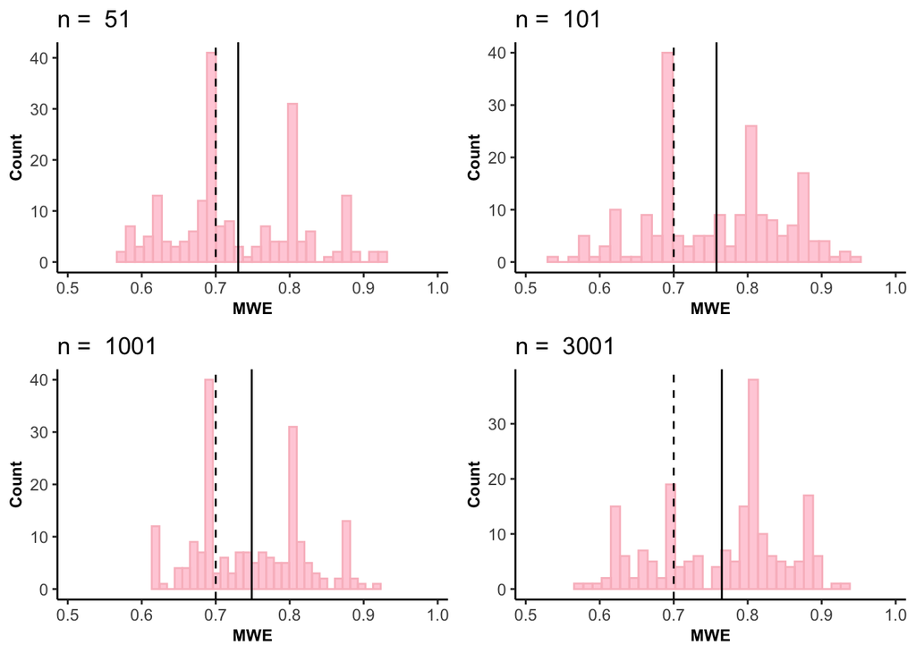

Four different FARIMA(0,d,0) processes for different sample sizes (n = 51, 101, 1001 and 3001). For the same process, we simulate 200 vectors following an exponential distribution and then compute the MWE. The figure represents the four histograms of the MWE. The dashed line is the true parameter H = 0.7 value and the full line is the mean of the MWE.

```r
set.seed(1991)
sim = 200

MWE_51 = numeric(sim)

# Simulate the process
n = 51
H = 0.7
y = longmemo::simARMA0(n, H = H)

# Compute the MWE using different seed
for (i in 1:sim){
  t = rexp(25, rate = 1)
  res = optimize(Wasserstein, lower = 0.51, upper = 0.99, maximum = FALSE,
                 theta = 0 , phi = 0, p = 1, q = 0, y = y, theoritical = t, weighted = FALSE, sinkhorn = FALSE)
  MWE_51[i] = res$minimum

}

p21 = ggplot(data = NULL, aes(x = MWE_51)) +
    geom_histogram(alpha=0.4,
               fill="#FF85A1",
               colour = "#F9BEC7") +
  theme_classic() +
  theme(axis.text=element_text(size=9),
        axis.title=element_text(size=9,face="bold")) +
  xlab("MWE") +
  ylab("Count") +
  ggtitle(paste("n = ", n)) +
  geom_vline(xintercept = mean(MWE_51))+
  coord_cartesian(xlim = c(0.51, 0.99)) +
  geom_vline(xintercept = H, linetype = "dashed")

set.seed(1992)
MWE_101 = numeric(sim)

# Simulate the process
n = 101
H = 0.7
y = longmemo::simARMA0(n, H = H)

# Compute the MWE using different seed
for (i in 1:sim){
  t = rexp(50, rate = 1)
  res = optimize(Wasserstein, lower = 0.51, upper = 0.99, maximum = FALSE,
                 theta = 0 , phi = 0, p = 1, q = 0, y = y, theoritical = t, weighted = FALSE, sinkhorn = FALSE)
  MWE_101[i] = res$minimum

}

p101 = ggplot(data = NULL, aes(x = MWE_101)) +
    geom_histogram(alpha=0.4,
               fill="#FF85A1",
               colour = "#F9BEC7") +
  theme_classic() +
  theme(axis.text=element_text(size=9),
        axis.title=element_text(size=9,face="bold")) +
  xlab("MWE") +
  ylab("Count") +
  ggtitle(paste("n = ", n)) +
  geom_vline(xintercept = mean(MWE_101))+
  coord_cartesian(xlim = c(0.51, 0.99)) +
  geom_vline(xintercept = H, linetype = "dashed")


set.seed(1414)
sim = 200

MWE_1001 = numeric(sim)

# Simulate the process
n = 1001
H = 0.7
y = longmemo::simARMA0(n, H = H)

# Compute the MWE using different seed
for (i in 1:sim){
  t = rexp(500, rate = 1)
  res = optimize(Wasserstein, lower = 0.51, upper = 0.99, maximum = FALSE,
                 theta = 0 , phi = 0, p = 1, q = 0, y = y, theoritical = t, weighted = FALSE, sinkhorn = FALSE)
  MWE_1001[i] = res$minimum

}

p1001 = ggplot(data = NULL, aes(x = MWE_1001)) +
    geom_histogram(alpha=0.4,
               fill="#FF85A1",
               colour = "#F9BEC7") +
  theme_classic() +
  theme(axis.text=element_text(size=9),
        axis.title=element_text(size=9,face="bold")) +
  xlab("MWE") +
  ylab("Count") +
  ggtitle(paste("n = ", n)) +
  geom_vline(xintercept = mean(MWE_1001)) +
  coord_cartesian(xlim = c(0.51, 0.99)) +
  geom_vline(xintercept = H, linetype = "dashed")

set.seed(9393)
sim = 200

MWE_3001 = numeric(sim)

# Simulate the process
n = 3001
H = 0.7
y = longmemo::simARMA0(n, H = H)

# Compute the MWE using different seed
for (i in 1:sim){
  t = rexp(1500, rate = 1)
  res = optimize(Wasserstein, lower = 0.51, upper = 0.99, maximum = FALSE,
                 theta = 0 , phi = 0, p = 1, q = 0, y = y, theoritical = t, weighted = FALSE, sinkhorn = FALSE)
  MWE_3001[i] = res$minimum

}

p3001 = ggplot(data = NULL, aes(x = MWE_3001)) +
    geom_histogram(alpha=0.4,
               fill="#FF85A1",
               colour = "#F9BEC7") +
  theme_classic() +
  theme(axis.text=element_text(size=9),
        axis.title=element_text(size=9,face="bold")) +
  xlab("MWE") +
  ylab("Count") +
  ggtitle(paste("n = ", n)) +
  geom_vline(xintercept = mean(MWE_3001))+
  coord_cartesian(xlim = c(0.51, 0.99)) +
  geom_vline(xintercept = H, linetype = "dashed")

ggarrange(p21, p101, p1001, p3001, nrow = 2, ncol =2)
```

## Mean of the Minimum Wasserstein Estimators

### Table 1

```r
set.seed(1414)
sim = 1

MWE = numeric(sim)

# Simulate the process
n = 3001
H = 0.7
y = longmemo::simARMA0(n, H = H)

# Compute the MWE using different seed
for (i in 1:sim){
  t = rexp(1500, rate = 1)
  res = optimize(Wasserstein, lower = 0.51, upper = 0.99, maximum = FALSE,
                 theta = 0 , phi = 0, p = 1, q = 0, y = y, theoritical = t, weighted = FALSE, sinkhorn = FALSE)
  MWE[i] = res$minimum

}

round(mean(MWE), digits = 3)
```

```
## [1] 0.807
```

```r
set.seed(1414)
sim = 10

MWE = numeric(sim)

# Simulate the process
n = 3001
H = 0.7
y = longmemo::simARMA0(n, H = H)

# Compute the MWE using different seed
for (i in 1:sim){
  t = rexp(1500, rate = 1)
  res = optimize(Wasserstein, lower = 0.51, upper = 0.99, maximum = FALSE,
                 theta = 0 , phi = 0, p = 1, q = 0, y = y, theoritical = t, weighted = FALSE, sinkhorn = FALSE)
  MWE[i] = res$minimum

}

round(mean(MWE), digits = 3)
```

```
## [1] 0.738
```

```r
set.seed(1414)
sim = 20

MWE = numeric(sim)

# Simulate the process
n = 3001
H = 0.7
y = longmemo::simARMA0(n, H = H)

# Compute the MWE using different seed
for (i in 1:sim){
  t = rexp(1500, rate = 1)
  res = optimize(Wasserstein, lower = 0.51, upper = 0.99, maximum = FALSE,
                 theta = 0 , phi = 0, p = 1, q = 0, y = y, theoritical = t, weighted = FALSE, sinkhorn = FALSE)
  MWE[i] = res$minimum

}
round(mean(MWE), digits = 3)
```

```
## [1] 0.736
```

```r
set.seed(1414)
sim =  50

MWE = numeric(sim)

# Simulate the process
n = 3001
H = 0.7
y = longmemo::simARMA0(n, H = H)

# Compute the MWE using different seed
for (i in 1:sim){
  t = rexp(1500, rate = 1)
  res = optimize(Wasserstein, lower = 0.51, upper = 0.99, maximum = FALSE,
                 theta = 0 , phi = 0, p = 1, q = 0, y = y, theoritical = t, weighted = FALSE, sinkhorn = FALSE)
  MWE[i] = res$minimum

}
round(mean(MWE), digits = 3)
```

```
## [1] 0.724
```

```r
set.seed(1414)
sim = 100

MWE = numeric(sim)

# Simulate the process
n = 3001
H = 0.7
y = longmemo::simARMA0(n, H = H)

# Compute the MWE using different seed
for (i in 1:sim){
  t = rexp(1500, rate = 1)
  res = optimize(Wasserstein, lower = 0.51, upper = 0.99, maximum = FALSE,
                 theta = 0 , phi = 0, p = 1, q = 0, y = y, theoritical = t, weighted = FALSE, sinkhorn = FALSE)
  MWE[i] = res$minimum

}
round(mean(MWE), digits = 3)
```

```
## [1] 0.726
```

```r
set.seed(1414)
sim = 200

MWE = numeric(sim)

# Simulate the process
n = 3001
H = 0.7
y = longmemo::simARMA0(n, H = H)

# Compute the MWE using different seed
for (i in 1:sim){
  t = rexp(1500, rate = 1)
  res = optimize(Wasserstein, lower = 0.51, upper = 0.99, maximum = FALSE,
                 theta = 0 , phi = 0, p = 1, q = 0, y = y, theoritical = t, weighted = FALSE, sinkhorn = FALSE)
  MWE[i] = res$minimum

}
round(mean(MWE), digits = 3)
```

```
## [1] 0.731
```

```r
set.seed(1414)
sim = 500

MWE = numeric(sim)

# Simulate the process
n = 3001
H = 0.7
y = longmemo::simARMA0(n, H = H)

# Compute the MWE using different seed
for (i in 1:sim){
  t = rexp(1500, rate = 1)
  res = optimize(Wasserstein, lower = 0.51, upper = 0.99, maximum = FALSE,
                 theta = 0 , phi = 0, p = 1, q = 0, y = y, theoritical = t, weighted = FALSE, sinkhorn = FALSE)
  MWE[i] = res$minimum

}
round(mean(MWE), digits = 3)
```

```
## [1] 0.726
```

```r
set.seed(1414)
sim = 1000

MWE = numeric(sim)

# Simulate the process
n = 3001
H = 0.7
y = longmemo::simARMA0(n, H = H)

# Compute the MWE using different seed
for (i in 1:sim){
  t = rexp(1500, rate = 1)
  res = optimize(Wasserstein, lower = 0.51, upper = 0.99, maximum = FALSE,
                 theta = 0 , phi = 0, p = 1, q = 0, y = y, theoritical = t, weighted = FALSE, sinkhorn = FALSE)
  MWE[i] = res$minimum

}
round(mean(MWE), digits = 3)
```

```
## [1] 0.726
```

### Figure 4

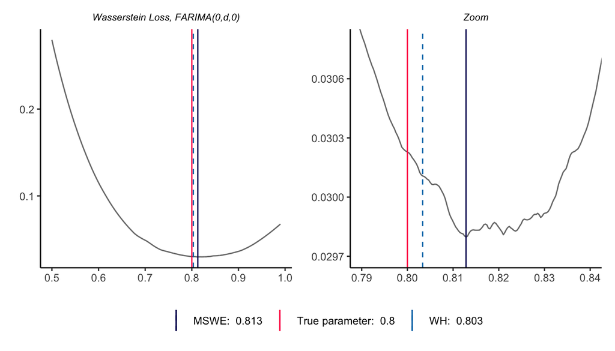

```r
set.seed(1414)
### Simulate time series
n = 3001
H = 0.8
p = 1
y = longmemo::simARMA0(n, H = H)

## Fundamental frequencies
m = length(y); mhalfm <- (m-1) %/% 2L
x <- 2*pi/m * (1:mhalfm)

### Compute the periodogram ordinates
per = (Mod(fft(y))^2/(2*pi*m)) [1:(m %/% 2 + 1)]
yper = periodogr.x = per[2:((m+1) %/% 2)]

### Parameter values
par = seq(0.5, 0.99, length.out = length(x))
m = length(par)

### Initialize matrices and vector(s)
per_ord_std = matrix(nrow=length(x), ncol=length(par));
spec = matrix(nrow=length(x), ncol=length(par))
px <- outer(x, 1:p)


### Compute the standardized periodogram ordinates
for (i in 1:length(x)){
  for (j in 1:length(par)){
    spec[i,j] = sqrt(2 - 2*cos(px[i]))^(1-2*par[j])
    per_ord_std[i,j]  = 2*pi * yper[i] / spec[i,j]
  }}


WD = c()
WH = c()

for (i in 1:ncol(per_ord_std)){
  ## Empirical CDF values
  fun.ecdf <- ecdf(per_ord_std[,i])
  my.ecdf <- fun.ecdf(sort(per_ord_std[,i]))

  WD[i] =  pracma::trapz(sort(per_ord_std[,i]) ,  abs(1- exp(-sort(per_ord_std[,i])) - my.ecdf))

  WH[i] = sum(per_ord_std[,i])
}


### Plot the Wasserstein loss function
p1 = ggplot(data = NULL, aes(x = par, y = WD)) + geom_line(alpha = 0.6) + theme_classic() +
  theme(plot.title = element_text(color = "black", size = 8, face = "italic", hjust = 0.5)) +
  labs(y = expression(""), x = expression(""),
       title = paste("Wasserstein Loss, FARIMA(0,d,0)")) +
  geom_vline(aes(xintercept = H, colour = paste("True parameter: ", H)), show.legend = T) +
  geom_vline(aes(xintercept = par[which.min(WD)], colour = paste("MSWE: ", round(par[which.min(WD)], digits = 3))), show.legend = T) +
   geom_vline(aes(xintercept = par[which.min(WH)], colour = paste("WH: ", round(par[which.min(WH)], digits = 3))), show.legend = T, linetype = "dashed") +
  scale_colour_manual(values = c("#03045E", "#FF0A54", "#0077B6"))

### Zoom

p2 = ggplot(data = NULL, aes(x = par, y = WD)) + geom_line(alpha = 0.6) + theme_classic() +
  theme(plot.title = element_text(color = "black", size = 8, face = "italic", hjust = 0.5)) +
  labs(y = expression(""), x = expression(""),
       title = paste("Zoom")) +
  geom_vline(aes(xintercept = H, colour = paste("True parameter: ", H)), show.legend = T) +
  geom_vline(aes(xintercept = par[which.min(WD)], colour = paste("MSWE: ", round(par[which.min(WD)], digits = 3))), show.legend = T) +
  geom_vline(aes(xintercept = par[which.min(WH)], colour = paste("WH: ", round(par[which.min(WH)], digits = 3))), show.legend = T, linetype = "dashed") +
  scale_colour_manual(values = c("#03045E", "#FF0A54", "#0077B6")) +
  coord_cartesian(xlim=c(0.79, 0.84), ylim=c((min(WD)-0.0001), (min(WD)+0.001)))


combined <- p1 + p2 & theme(legend.title = element_blank(), legend.position = 'bottom')
combined + plot_layout(guides = "collect")
```

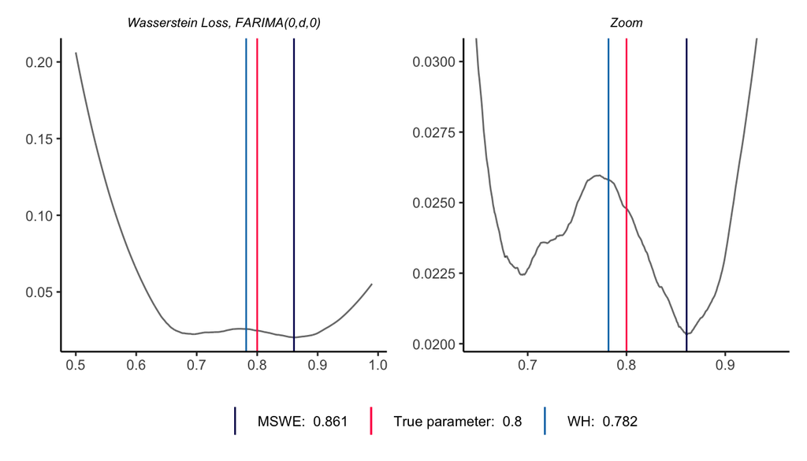

Semidiscrete Wasserstein loss functions for two FARIMA(0,d,0) processes. The sample size is 3001 and the true parameter value is 0.8.

```r
set.seed(2345)
### Simulate time series
n = 3001
H = 0.8
y = longmemo::simARMA0(n, H = H)

## Fundamental frequencies
m = length(y); mhalfm <- (m-1) %/% 2L
x <- 2*pi/m * (1:mhalfm)

### Compute the periodogram ordinates
per = (Mod(fft(y))^2/(2*pi*m)) [1:(m %/% 2 + 1)]
yper = periodogr.x = per[2:((m+1) %/% 2)]

### Parameter values
par = seq(0.5, 0.99, length.out = length(x))
m = length(par)

### Initialize matrices and vector(s)
per_ord_std = matrix(nrow=length(x), ncol=length(par));
spec = matrix(nrow=length(x), ncol=length(par))
px <- outer(x, 1:p)


### Compute the standardized periodogram ordinates
for (i in 1:length(x)){
  for (j in 1:length(par)){
    spec[i,j] = sqrt(2 - 2*cos(px[i]))^(1-2*par[j])
    per_ord_std[i,j]  = 2*pi * yper[i] / spec[i,j]
  }}

WD_2 = c()
WH_2 = c()

for (i in 1:ncol(per_ord_std)){
  ## Empirical CDF values
  fun.ecdf <- ecdf(per_ord_std[,i])
  my.ecdf <- fun.ecdf(sort(per_ord_std[,i]))

  WD_2[i] =  pracma::trapz(sort(per_ord_std[,i]) ,  abs(1- exp(-sort(per_ord_std[,i])) - my.ecdf))

  WH_2[i] = sum(per_ord_std[,i])
}


### Plot the Wasserstein loss function
p3 = ggplot(data = NULL, aes(x = par, y = WD_2)) + geom_line(alpha = 0.6) + theme_classic() +
  theme(plot.title = element_text(color = "black", size = 8, face = "italic", hjust = 0.5)) +
  labs(y = expression(""), x = expression(""),
       title = paste("Wasserstein Loss, FARIMA(0,d,0)")) +
  geom_vline(aes(xintercept = H, colour = paste("True parameter: ", H)), show.legend = T) +
  geom_vline(aes(xintercept = par[which.min(WD_2)], colour = paste("MSWE: ", round(par[which.min(WD_2)], digits = 3))), show.legend = T) +
  geom_vline(aes(xintercept = par[which.min(WH_2)], colour = paste("WH: ", round(par[which.min(WH_2)], digits = 3))), show.legend = T) +
  scale_colour_manual(values = c("#03045E", "#FF0A54", "#0077B6"))

### Zoom

p4 = ggplot(data = NULL, aes(x = par, y = WD_2)) + geom_line(alpha = 0.6) + theme_classic() +
  theme(plot.title = element_text(color = "black", size = 8, face = "italic", hjust = 0.5)) +
  labs(y = expression(""), x = expression(""),
       title = paste("Zoom")) +
  geom_vline(aes(xintercept = H, colour = paste("True parameter: ", H)), show.legend = T) +
  geom_vline(aes(xintercept = par[which.min(WD_2)], colour = paste("MSWE: ", round(par[which.min(WD_2)], digits = 3))), show.legend = T) +
  geom_vline(aes(xintercept = par[which.min(WH_2)], colour = paste("WH: ", round(par[which.min(WH_2)], digits = 3))), show.legend = T) +
  scale_colour_manual(values = c("#03045E", "#FF0A54", "#0077B6")) +
   coord_cartesian(xlim=c(0.65, 0.95), ylim=c((min(WD_2)-0.0001), (min(WD_2)+0.01)))



combined <- p3 + p4 & theme(legend.title = element_blank(), legend.position = 'bottom')
combined + plot_layout(guides = "collect")
```

### Figure 5

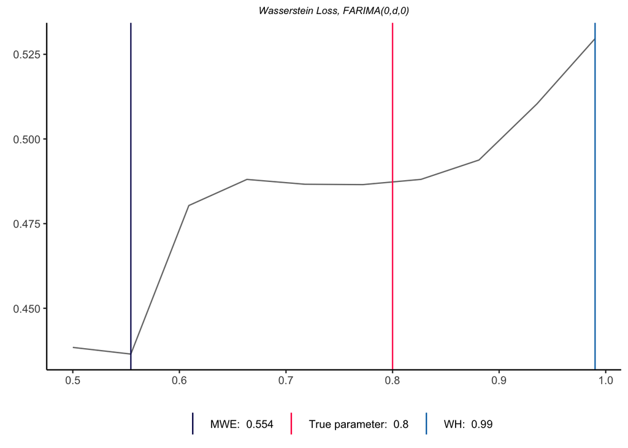

Wasserstein loss function for a small sample size (n = 21) FARIMA(0,d,0) process.

```r
set.seed(1263)
### Simulate time series
n = 21
H = 0.8
y = longmemo::simARMA0(n, H = H)

## Fundamental frequencies
m = length(y); mhalfm <- (m-1) %/% 2L
x <- 2*pi/m * (1:mhalfm)

### Compute the periodogram ordinates
per = (Mod(fft(y))^2/(2*pi*m)) [1:(m %/% 2 + 1)]
yper = periodogr.x = per[2:((m+1) %/% 2)]

### Parameter values
par = seq(0.5, 0.99, length.out = length(x))
m = length(par)

### Initialize matrices and vector(s)
per_ord_std = matrix(nrow=length(x), ncol=length(par));
spec = matrix(nrow=length(x), ncol=length(par))
px <- outer(x, 1:p)
WD_2 = rep(NA, m)
WH_2 = rep(NA, m)

### Compute the standardized periodogram ordinates
for (i in 1:length(x)){
  for (j in 1:length(par)){
    spec[i,j] = sqrt(2 - 2*cos(px[i]))^(1-2*par[j])
    per_ord_std[i,j]  = 2*pi * yper[i] / spec[i,j]
  }}

### Generate the random vector of Exponential(1) variables
set.seed(5474)
t = rexp(10,rate  = 1)

### Compute the 1-Wasserstein distance between the SPOs and t
p = 1
for (i in 1:length(per_ord_std[,i])){
  WD_2[i] = (mean(abs(sort(t) - sort(per_ord_std[,i]))^p)^(1/p))
  WH_2[i] = sum(per_ord_std[,i])
}

### Plot the Wasserstein loss function
p3 = ggplot(data = NULL, aes(x = par, y = WD_2)) + geom_line(alpha = 0.6) + theme_classic() +
  theme(plot.title = element_text(color = "black", size = 8, face = "italic", hjust = 0.5)) +
  labs(y = expression(""), x = expression(""),
       title = paste("Wasserstein Loss, FARIMA(0,d,0)")) +
  geom_vline(aes(xintercept = H, colour = paste("True parameter: ", H)), show.legend = T) +
  geom_vline(aes(xintercept = par[which.min(WD_2)], colour = paste("MWE: ", round(par[which.min(WD_2)], digits = 3))), show.legend = T) +
  geom_vline(aes(xintercept = par[which.min(WH_2)], colour = paste("WH: ", round(par[which.min(WH_2)], digits = 3))), show.legend = T) +
  scale_colour_manual(values = c("#03045E", "#FF0A54", "#0077B6")) +
  theme(legend.title = element_blank(), legend.position = 'bottom')

p3
```

## Minimum Weighted Wasserstein Estimators

### Figure 6

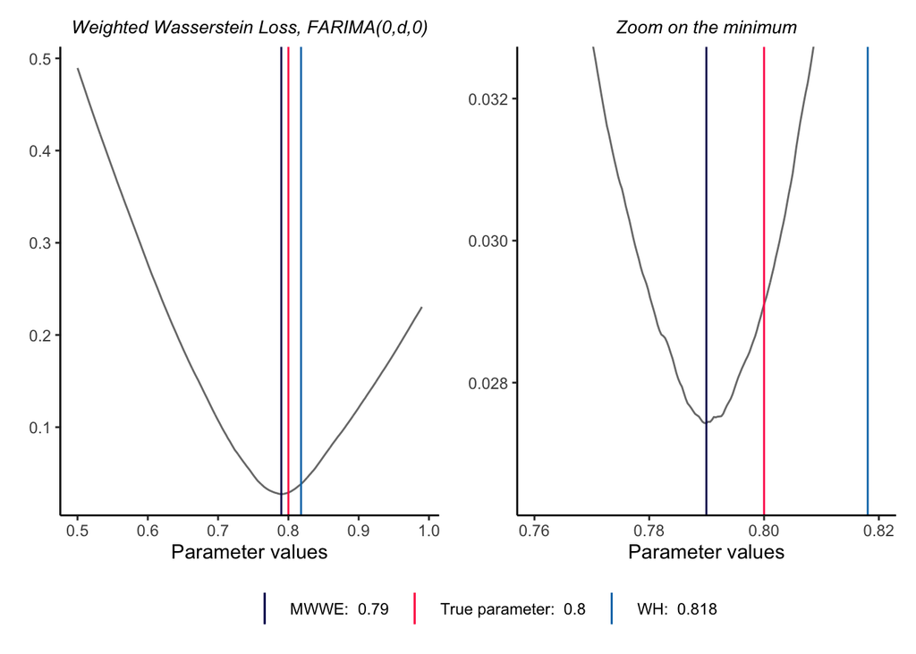

Weighted Wasserstein loss function of the FARIMA(0,d,0) process on Figure 1 (bottom).

```r
set.seed(3459)
### Simulate time series
n = 3001
H = 0.8
y = longmemo::simARMA0(n, H = H)

## Fundamental frequencies
m = length(y); mhalfm <- (m-1) %/% 2L
x <- 2*pi/m * (1:mhalfm)

### Compute the periodogram ordinates
per = (Mod(fft(y))^2/(2*pi*m)) [1:(m %/% 2 + 1)]
yper = periodogr.x = per[2:((m+1) %/% 2)]

### Parameter values
par = seq(0.5, 0.99, length.out = length(x))
m = length(par)

### Initialize matrices and vector(s)
per_ord_std = matrix(nrow=length(x), ncol=length(par));
spec = matrix(nrow=length(x), ncol=length(par))
px <- outer(x, 1:p)
WD = numeric(m)
WH = numeric(m)

### Compute the standardized periodogram ordinates
for (i in 1:length(x)){
  for (j in 1:length(par)){
    spec[i,j] = sqrt(2 - 2*cos(px[i]))^(1-2*par[j])
    per_ord_std[i,j]  = 2*pi * yper[i] / spec[i,j]
  }}

### Generate the random vector of Exponential(1) variables
set.seed(8764)
t = rexp(1500,rate  = 1)

### Compute the 1-Wasserstein distance between the SPOs and t
p = 1
for (i in 1:length(per_ord_std[,i])){
  weight = per_ord_std[,i] / sum(per_ord_std[,i])
  WD[i] = transport::wasserstein1d(t, per_ord_std[,i],  wa = NULL, wb = weight, p = 1)
  WH[i] = sum(per_ord_std[,i])
}

p6 = ggplot(data = NULL, aes(x = par, y = WD)) + geom_line(alpha = 0.6) + theme_classic() +
  theme(plot.title = element_text(color = "black", size = 10, face = "italic", hjust = 0.5)) +
  labs(y = expression(""), x = expression("Parameter values"),
       title = paste("Weighted Wasserstein Loss, FARIMA(0,d,0)")) +
  geom_vline(aes(xintercept = H, colour = paste("True parameter: ", H)), show.legend = T) +
  geom_vline(aes(xintercept = par[which.min(WD)], colour = paste("MWWE: ", round(par[which.min(WD)], digits = 3))), show.legend = T) +
  geom_vline(aes(xintercept = par[which.min(WH)], colour = paste("WH: ", round(par[which.min(WH)], digits = 3))), show.legend = T) +
  scale_colour_manual(values = c("#03045E", "#FF0A54", "#0077B6"))

p7 = ggplot(data = NULL, aes(x = par, y = WD)) + geom_line(alpha = 0.6) + theme_classic() +
  theme(plot.title = element_text(color = "black", size = 10, face = "italic", hjust = 0.5)) +
  labs(y = expression(""), x = expression("Parameter values"),
       title = paste("Zoom on the minimum")) +
  geom_vline(aes(xintercept = H, colour = paste("True parameter: ", H)), show.legend = T) +
  geom_vline(aes(xintercept = par[which.min(WD)], colour = paste("MWWE: ", round(par[which.min(WD)], digits = 3))), show.legend = T) +
  geom_vline(aes(xintercept = par[which.min(WH)], colour = paste("WH: ", round(par[which.min(WH)], digits = 3))), show.legend = T) +
  scale_colour_manual(values = c("#03045E", "#FF0A54", "#0077B6")) +
   coord_cartesian(xlim=c(0.76, 0.82), ylim=c((min(WD)-0.001), (min(WD)+0.005)))


combined <- p6 + p7 & theme(legend.title = element_blank(), legend.position = 'bottom')
combined + plot_layout(guides = "collect")
```

### Figure 7

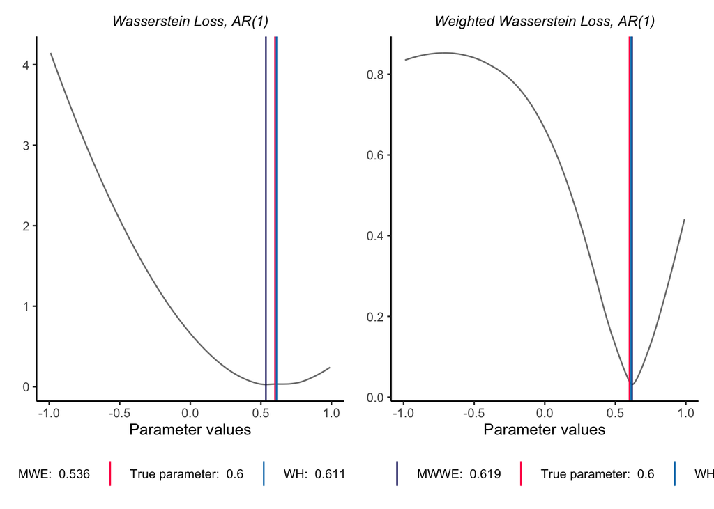

Wasserstein loss and weighted Wasserstein loss functions of a Gaussian AR(1) process. The sample size is 3001 and the true parameter is 0.6.

```r
set.seed(8677)
### Simulate time series
n = 3001
theta0 = 0.6
p = 1
y <- arima.sim(n = n, list(ar = theta0), rand.gen = rnorm, sd = 1)

## Fundamental frequencies
m = length(y); mhalfm <- (m-1) %/% 2L
x <- 2*pi/m * (1:mhalfm)

### Compute the periodogram ordinates
per = (Mod(fft(y))^2/(2*pi*m)) [1:(m %/% 2 + 1)]
yper = periodogr.x = per[2:((m+1) %/% 2)]

### Parameter values
par = seq(-0.99, 0.99, length.out = length(x))
m = length(par)

### Initialize matrices and vector(s)
per_ord_std = matrix(nrow=length(x), ncol=length(par));
spec = matrix(nrow=length(x), ncol=length(par))
px <- outer(x, 1:p)
WD = numeric(m)
WH = numeric(m)
WD_w = numeric(m)

### Compute the standardized periodogram ordinates
for (i in 1:length(x)){
  for (j in 1:length(par)){
    Rar <- cos(px[i]) %*% par[j]
    Iar <- sin(px[i]) %*% par[j]
    far = (1-Rar)^2 + Iar^2
    spec[i,j] = 1/far
    per_ord_std[i,j]  = 2*pi * yper[i] / spec[i,j]
  }}

### Generate the random vector of Exponential(1) variables
set.seed(3456)
t = rexp(1500,rate  = 1)

### Compute the 1-Wasserstein distance between the SPOs and t
p = 1
for (i in 1:length(per_ord_std[,i])){
  weight = per_ord_std[,i] / sum(per_ord_std[,i])
  WD[i] = transport::wasserstein1d(t, per_ord_std[,i],  wa = NULL, wb = NULL, p = 1)
  WH[i] = sum(per_ord_std[,i])
  WD_w [i]= transport::wasserstein1d(t, per_ord_std[,i],  wa = NULL, wb = weight, p = 1)
}


### Plot the Wasserstein loss function
a1 = ggplot(data = NULL, aes(x = par, y = WD)) + geom_line(alpha = 0.6) +
  theme_classic() +
  theme(plot.title = element_text(color = "black", size = 10, face = "italic", hjust = 0.5)) +
  labs(y = expression(""), x = expression("Parameter values"),
       title = paste("Wasserstein Loss, AR(1)")) +
  geom_vline(aes(xintercept = theta0, colour = paste("True parameter: ", theta0)), show.legend = T) +
  geom_vline(aes(xintercept = par[which.min(WD)], colour = paste("MWE: ", round(par[which.min(WD)], digits = 3))), show.legend = T) +
  geom_vline(aes(xintercept = par[which.min(WH)], colour = paste("WH: ", round(par[which.min(WH)], digits = 3))), show.legend = T) +
  theme(legend.title = element_blank(), legend.position = 'bottom') +
  scale_colour_manual(values = c("#03045E", "#FF0A54", "#0077B6"))

a2 = ggplot(data = NULL, aes(x = par, y = WD_w)) + geom_line(alpha = 0.6) +
  theme_classic() +
  theme(plot.title = element_text(color = "black", size = 10, face = "italic", hjust = 0.5)) +
  labs(y = expression(""), x = expression("Parameter values"),
       title = paste("Weighted Wasserstein Loss, AR(1)")) +
  geom_vline(aes(xintercept = theta0, colour = paste("True parameter: ", theta0)), show.legend = T) +
  geom_vline(aes(xintercept = par[which.min(WD_w)], colour = paste("MWWE: ", round(par[which.min(WD_w)], digits = 3))), show.legend = T) +
  geom_vline(aes(xintercept = par[which.min(WH)], colour = paste("WH: ", round(par[which.min(WH)], digits = 3))), show.legend = T) +
  theme(legend.title = element_blank(), legend.position = 'bottom') +
  scale_colour_manual(values = c("#03045E", "#FF0A54", "#0077B6"))

combined <- a1 + a2 & theme(legend.title = element_blank(), legend.position = 'bottom')
combined + plot_layout(guides = "collect")
```

##Minimum Sinkhorn Estimator

### Figure 8

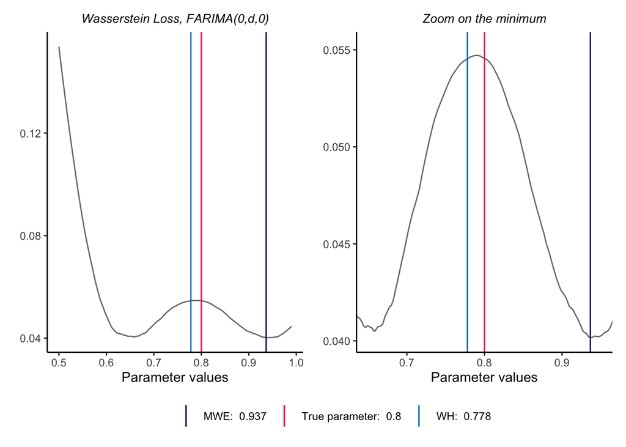

```r
set.seed(87597684)
### Simulate time series
n = 1801
H = 0.8
p = 1
#library(arfima)
#arfima.sim(1000, model = list(phi = .2, dfrac = .3, dint = 2))
#y = arfima.sim(3001, model = list(H = H))
#y = longmemo::simARMA0(n, H = H)
y = fracdiff::fracdiff.sim(n, d = H - 1/2)
y = y$series


## Fundamental frequencies
m = length(y); mhalfm <- (m-1) %/% 2L
x <- 2*pi/m * (1:mhalfm)

### Compute the periodogram ordinates
per = (Mod(fft(y))^2/(2*pi*m)) [1:(m %/% 2 + 1)]
yper = periodogr.x = per[2:((m+1) %/% 2)]

### Parameter values
par = seq(0.5, 0.99, length.out = length(x))
m = length(par)

### Initialize matrices and vector(s)
per_ord_std = matrix(nrow=length(x), ncol=length(par));
spec = matrix(nrow=length(x), ncol=length(par))
px <- outer(x, 1:p)
WD = numeric(m)
WH = numeric(m)

### Compute the standardized periodogram ordinates
for (i in 1:length(x)){
  for (j in 1:length(par)){
    spec[i,j] = sqrt(2 - 2*cos(px[i]))^(1-2*par[j])
    per_ord_std[i,j]  = 2*pi * yper[i] / spec[i,j]
  }}

### Generate the random vector of Exponential(1) variables
set.seed(1256)
t = rexp(m,rate  = 1)

### Compute the 1-Wasserstein distance between the SPOs and t
p = 1
for (i in 1:length(per_ord_std[,i])){
    WD[i] = (mean(abs(sort(t) - sort(per_ord_std[,i]))^p)^(1/p))
    WH[i] = sum(per_ord_std[,i])
}

### Plot the Sinkhorn loss function
p8 = ggplot(data = NULL, aes(x = par, y = WD)) + geom_line(alpha = 0.6) + theme_classic() +
  theme(plot.title = element_text(color = "black", size = 10, face = "italic", hjust = 0.5)) +
  labs(y = expression(""), x = expression("Parameter values"),
       title = paste("Wasserstein Loss, FARIMA(0,d,0)")) +
  geom_vline(aes(xintercept = H, colour = paste("True parameter: ", H)), show.legend = T) +
  geom_vline(aes(xintercept = par[which.min(WD)], colour = paste("MWE: ", round(par[which.min(WD)], digits = 3))), show.legend = T) +
  geom_vline(aes(xintercept = par[which.min(WH)], colour = paste("WH: ", round(par[which.min(WH)], digits = 3))), show.legend = T) +
  scale_colour_manual(values = c("#03045E", "#FF0A54", "#0077B6"))


## Zoom

p9 = ggplot(data = NULL, aes(x = par, y = WD)) + geom_line(alpha = 0.6) + theme_classic() +
  theme(plot.title = element_text(color = "black", size = 10, face = "italic", hjust = 0.5)) +
  labs(y = expression(""), x = expression("Parameter values"),
       title = paste("Zoom on the minimum")) +
  geom_vline(aes(xintercept = H, colour = paste("True parameter: ", H)), show.legend = T) +
  geom_vline(aes(xintercept = par[which.min(WD)], colour = paste("MWE: ", round(par[which.min(WD)], digits = 3))), show.legend = T) +
  geom_vline(aes(xintercept = par[which.min(WH)], colour = paste("WH: ", round(par[which.min(WH)], digits = 3))), show.legend = T) +
  scale_colour_manual(values = c("#03045E", "#FF0A54", "#0077B6")) +
  coord_cartesian(xlim=c(H-0.15,H+0.15), ylim=c((min(WD)-0.00001), (min(WD)+0.015)))

combined <- p8 + p9 & theme(legend.title = element_blank(), legend.position = 'bottom')
combined + plot_layout(guides = "collect")
```

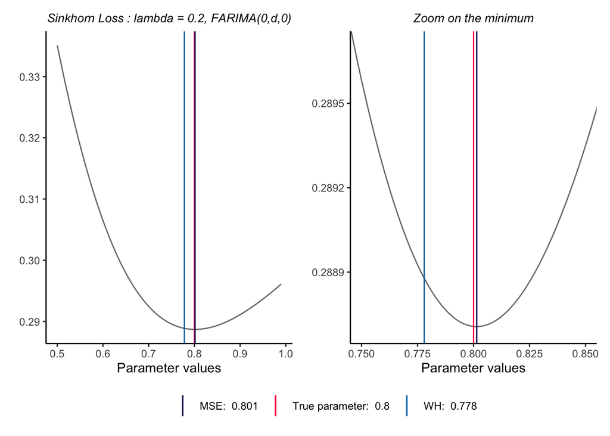

Top: Wasserstein loss function of a FARIMA(0,d,0) process. Bottom: Sinkhorn loss function of the same process. The sample size is 1801.

```r
set.seed(87597684)
### Simulate time series
n = 1801
H = 0.8
#library(arfima)
#arfima.sim(1000, model = list(phi = .2, dfrac = .3, dint = 2))
#y = arfima.sim(3001, model = list(H = H))
#y = longmemo::simARMA0(n, H = H)
y = fracdiff::fracdiff.sim(n, d = H - 1/2)
y = y$series


## Fundamental frequencies
m = length(y); mhalfm <- (m-1) %/% 2L
x <- 2*pi/m * (1:mhalfm)

### Compute the periodogram ordinates
per = (Mod(fft(y))^2/(2*pi*m)) [1:(m %/% 2 + 1)]
yper = periodogr.x = per[2:((m+1) %/% 2)]

### Parameter values
par = seq(0.5, 0.99, length.out = length(x))
m = length(par)

### Initialize matrices and vector(s)
per_ord_std = matrix(nrow=length(x), ncol=length(par));
spec = matrix(nrow=length(x), ncol=length(par))
px <- outer(x, 1:p)
SH_bary_farima = numeric(m)
WH = numeric(m)

### Compute the standardized periodogram ordinates
for (i in 1:length(x)){
  for (j in 1:length(par)){
    spec[i,j] = sqrt(2 - 2*cos(px[i]))^(1-2*par[j])
    per_ord_std[i,j]  = 2*pi * yper[i] / spec[i,j]
  }}

### Generate the random vector of Exponential(1) variables
set.seed(1256)
t = rexp(m,rate  = 1)

### Compute the 1-Wasserstein distance between the SPOs and t
p = 1
lambda = 0.2
for (i in 1:length(per_ord_std[,i])){
    x = as.matrix(per_ord_std[,i]/ sum(per_ord_std[,i]))
    z = as.matrix(t/sum(t))
    size <- seq(0,1,length.out =30)
    costm <- as.matrix(dist(expand.grid(size,rev(size)), diag=TRUE, upper=TRUE))

    SH_bary_farima[i] = Barycenter::Sinkhorn(x, z, costm, lambda = lambda)$Distance
    WH[i] = sum(per_ord_std[,i])
}



### Plot the Wasserstein loss function
p10 = ggplot(data = NULL, aes(x = par, y = SH_bary_farima)) + geom_line(alpha = 0.6) + theme_classic() +
  theme(plot.title = element_text(color = "black", size = 10, face = "italic", hjust = 0.5)) +
  labs(y = expression(""), x = expression("Parameter values"),
       title = paste("Sinkhorn Loss :", expression(lambda), "= 0.2, FARIMA(0,d,0)")) +
  geom_vline(aes(xintercept = H, colour = paste("True parameter: ", H)), show.legend = T) +
  geom_vline(aes(xintercept = par[which.min(SH_bary_farima)], colour = paste("MSE: ", round(par[which.min(SH_bary_farima)], digits = 3))), show.legend = T) +
  geom_vline(aes(xintercept = par[which.min(WH)], colour = paste("WH: ", round(par[which.min(WH)], digits = 3))), show.legend = T) +
  scale_colour_manual(values = c("#03045E", "#FF0A54", "#0077B6"))


## Zoom

p11 = ggplot(data = NULL, aes(x = par, y = SH_bary_farima)) + geom_line(alpha = 0.6) + theme_classic() +
  theme(plot.title = element_text(color = "black", size = 10, face = "italic", hjust = 0.5)) +
  labs(y = expression(""), x = expression("Parameter values"),
       title = paste("Zoom on the minimum")) +
  geom_vline(aes(xintercept = H, colour = paste("True parameter: ", H)), show.legend = T) +
  geom_vline(aes(xintercept = par[which.min(SH_bary_farima)], colour = paste("MSE: ", round(par[which.min(SH_bary_farima)], digits = 3))), show.legend = T) +
  geom_vline(aes(xintercept = par[which.min(WH)], colour = paste("WH: ", round(par[which.min(WH)], digits = 3))), show.legend = T) +
  scale_colour_manual(values = c("#03045E", "#FF0A54", "#0077B6")) +
  coord_cartesian(xlim=c(H-0.05,H+0.05), ylim=c((min(SH_bary_farima)-0.00001), (min(SH_bary_farima)+0.001)))

combined <- p10 + p11 & theme(legend.title = element_blank(), legend.position = 'bottom')
combined + plot_layout(guides = "collect")
```

### Figure 9

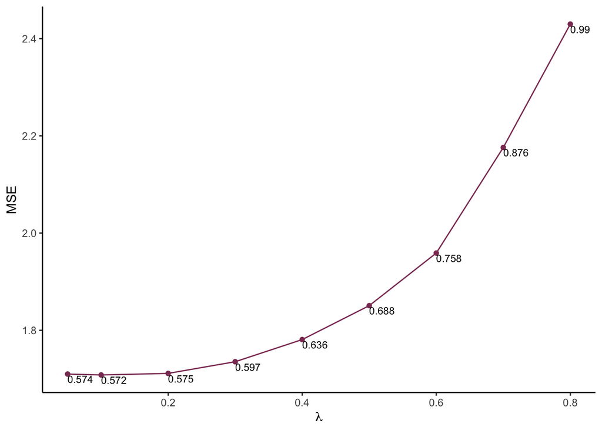

Testing MSE vs lambda values for an AR(1) process. The sample size is 4001 and the true parameter value is 0.6. For this process, the minimum MSE is achieved when lambda = 0.1.

```r
set.seed(4545)
n = 4001
theta0 = 0.6
y <- arima.sim(n = n, list(ar = theta0), rand.gen = rnorm, sd = 1)

set.seed(986)
t = rexp(1600, rate = 1)

## Split data into train & test
library(caret)
intrain<-createDataPartition(y ,p = 0.8, list=FALSE)
train<- y[intrain]
test<-y[-intrain]

lambda = c(0.05, 0.1, 0.2, 0.3, 0.4, 0.5, 0.6, 0.7, 0.8)
MSE = numeric(length(lambda))
par = numeric(length(lambda))

for (j in 1:length(lambda)){
  res = optimize(Wasserstein, lower = -0.99, upper = 0.99, maximum = FALSE, H = 1/2, phi = 0, p = 1, q = 0, y = train, theoritical = t, weighted = FALSE, sinkhorn = TRUE, lambda = lambda[j])
  par[j] = res$minimum

  # predictions on test
  n = length(test)
  resid = test[2:n] - par[j] * test[1:n-1]
  MSE[j] = (1/n) * sum((resid)^2)
}


data.point = as.data.frame(cbind(lambda,MSE, par = round(par, digits = 3)))

ggplot(data = data.point, aes(x = lambda, y = MSE), label = par) + geom_point(col = "hotpink4") + geom_line(col = "hotpink4") + geom_text(size = 3, aes(label=par),hjust=0, vjust=1.2) + theme_classic() +
  xlab(expression(lambda))
```

# Results

## Long-memory Process

### Figure 10

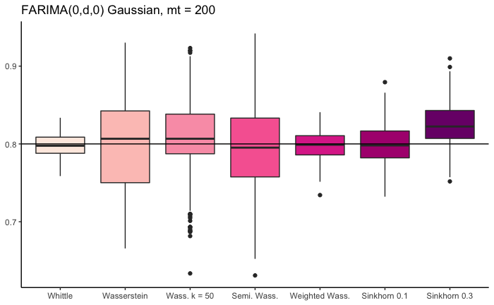

Boxplots of all the estimators presented during this thesis. The sample size of the 200 simulated FARIMA(0,d,0) is 3201.

```r
knitr::include_graphics("/Users/manonfelix/OneDrive/Master thesis/Redaction/images/box_farima_t200.png")
```

```r
mt = 200

WH_G1 = numeric(mt)
WD_G1 = numeric(mt)
Weighted_WD_G1 = numeric(mt)
WD_cdf_G1 = numeric(mt)
WD_mean_G1 = numeric(mt)
SH_01_G1 = numeric(mt)
SH_03_G1 = numeric(mt)

set.seed(1405)
for (i in 1:mt){
  n = 3201
  H = 0.8
  y <- longmemo::simARMA0(n, H)
  t = rexp(1600, rate = 1)

  res = optimize(Whittle, lower = 0.51, upper = 0.99, maximum = FALSE, theta = 0, phi = 0, p = 0, q = 0, y = y)
  WH_G1[i] = res$minimum

  res = optimize(Wasserstein, lower = 0.51, upper = 0.99, maximum = FALSE, theta = 0 , phi = 0, p = 0, q = 0, y = y, theoritical = t)
  WD_G1[i] = res$minimum

  res = optimize(Wasserstein, lower = 0.51, upper = 0.99, maximum = FALSE, theta = 0 , phi = 0, p = 0, q = 0, y = y, theoritical = t, mean = TRUE, k = 50)
  WD_mean_G1[i] = res$minimum

  res = optimize(Wasserstein, lower = 0.51, upper = 0.99, maximum = FALSE, theta = 0 , phi = 0, p = 0, q = 0, y = y, theoritical = t, cdf = TRUE)
  WD_cdf_G1[i] = res$minimum

  res = optimize(Wasserstein, lower = 0.51, upper = 0.99, maximum = FALSE, theta = 0 , phi = 0, p = 0, q = 0, y = y, theoritical = t, weighted = TRUE)
  Weighted_WD_G1[i] = res$minimum

  res = optimize(Wasserstein, lower = 0.51, upper = 0.99, maximum = FALSE, theta = 0, phi = 0, p = 0, q = 0, y = y, theoritical = t, weighted = FALSE, sinkhorn = TRUE, lambda = 0.1)
  SH_01_G1[i] = res$minimum

  res = optimize(Wasserstein, lower = 0.51, upper = 0.99, maximum = FALSE, theta = 0, phi = 0, p = 0, q = 0, y = y, theoritical = t, weighted = FALSE, sinkhorn = TRUE, lambda = 0.3)
  SH_03_G1[i] = res$minimum
}
```

```r
a = data.frame(group = "Whittle", value = WH_G1)
b = data.frame(group = "Wass.", value = WD_G1)
c = data.frame(group = "Weighted Wass.", value = Weighted_WD_G1)
d = data.frame(group = "Semi. Wass.", value = WD_cdf_G1)
e = data.frame(group = "Wass. k = 50", value = WD_mean_G1)
f = data.frame(group = "Sink. 0.1", value = SH_01_G1)
g = data.frame(group = "Sink. 0.3", value = SH_03_G1)

H = 0.8


plot.data = rbind(a, b, c, d ,e,f,g)
plot.data

mse = cbind(a, b, c, d, e,f,g)
mse = as.data.frame(mse)



library(ggplot2)
ggplot(plot.data, aes(x=group, y=Re(value), fill=group)) +
  geom_boxplot()+
  theme_classic() +
  theme(legend.position = "none") +
  geom_hline(yintercept = H) +
  theme(axis.title.x=element_blank()) +
  theme(axis.title.y=element_blank()) +
  ggtitle("n = 1801, FARIMA(0,d,0) Gaussian, mt = 200")+
  scale_fill_brewer(palette = "RdPu")

boxplot(plot.data$value ~ plot.data$group , col=rgb(0.3,0.5,0.4,0.6) , ylab="value" , xlab="names in desired order")


for (i in c(2,4,6,8,10,12,14)){
  MSE = sum((mse[,i] - theta0)^2)
  print(paste(mse[1,i-1], ": MSE = ", round(MSE, digits = 5)))
}
```

### Figure 11

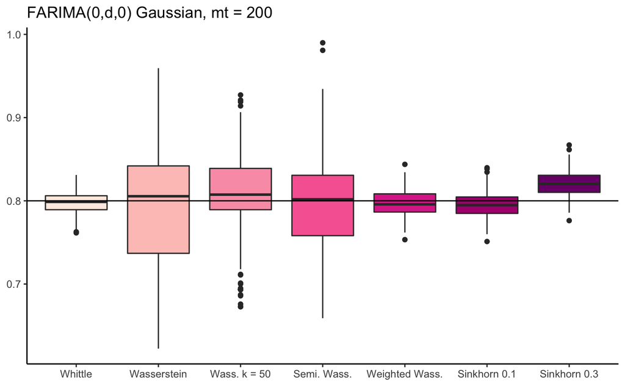

Boxplots of all the estimators presented during this thesis. The sample size of the 200 simulated FARIMA(0,d,0) is 3201. All the estimators are computed using a unique random vector.

```r
knitr::include_graphics("/Users/manonfelix/OneDrive/Master thesis/Redaction/images/boxplot_farima_t1.png")
```

```r
mt = 200

set.seed(1405)
t = rexp(1600, rate = 1)

WH_G1 = numeric(mt)
WD_G1 = numeric(mt)
Weighted_WD_G1 = numeric(mt)
WD_cdf_G1 = numeric(mt)
WD_mean_G1 = numeric(mt)
SH_01_G1 = numeric(mt)
SH_03_G1 = numeric(mt)

for (i in 1:mt){
  n = 3201
  H = 0.8
  y <- longmemo::simARMA0(n, H)

  res = optimize(Whittle, lower = 0.51, upper = 0.99, maximum = FALSE, theta = 0, phi = 0, p = 0, q = 0, y = y)
  WH_G1[i] = res$minimum

  res = optimize(Wasserstein, lower = 0.51, upper = 0.99, maximum = FALSE, theta = 0 , phi = 0, p = 0, q = 0, y = y, theoritical = t)
  WD_G1[i] = res$minimum

  res = optimize(Wasserstein, lower = 0.51, upper = 0.99, maximum = FALSE, theta = 0 , phi = 0, p = 0, q = 0, y = y, theoritical = t, mean = TRUE, k = 50)
  WD_mean_G1[i] = res$minimum

  res = optimize(Wasserstein, lower = 0.51, upper = 0.99, maximum = FALSE, theta = 0 , phi = 0, p = 0, q = 0, y = y, theoritical = t, cdf = TRUE)
  WD_cdf_G1[i] = res$minimum

  res = optimize(Wasserstein, lower = 0.51, upper = 0.99, maximum = FALSE, theta = 0 , phi = 0, p = 0, q = 0, y = y, theoritical = t, weighted = TRUE)
  Weighted_WD_G1[i] = res$minimum

  res = optimize(Wasserstein, lower = 0.51, upper = 0.99, maximum = FALSE, theta = 0, phi = 0, p = 0, q = 0, y = y, theoritical = t, weighted = FALSE, sinkhorn = TRUE, lambda = 0.1)
  SH_01_G1[i] = res$minimum

  res = optimize(Wasserstein, lower = 0.51, upper = 0.99, maximum = FALSE, theta = 0, phi = 0, p = 0, q = 0, y = y, theoritical = t, weighted = FALSE, sinkhorn = TRUE, lambda = 0.3)
  SH_03_G1[i] = res$minimum
}
```

#### Heavy-Tailed Distribution

##### Figure 12

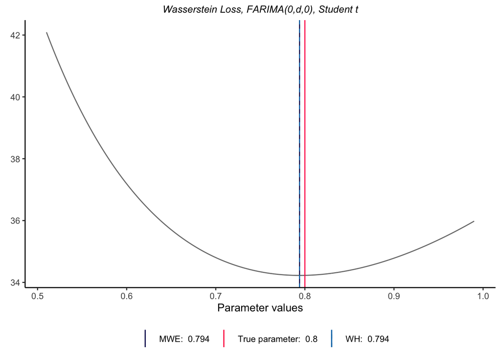

Wasserstein loss function of a FARIMA(0,d,0) process distributed according to a Student t distribution with degree of freedom equal to 2. The sample size is equal to 3001.

```r
#FARIMA(0,d,0) following a Student t distribution
set.seed(6565)
n = 3001
H = 0.8
y = fracdiff::fracdiff.sim(n, d = H - 1/2, rand.gen = rt , df = 2)
y = y$series
p = 1

## Fundamental frequencies
m = length(y); mhalfm <- (m-1) %/% 2L
x <- 2*pi/m * (1:mhalfm)

### Compute the periodogram ordinates
per = (Mod(fft(y))^2/(2*pi*m)) [1:(m %/% 2 + 1)]
yper = periodogr.x = per[2:((m+1) %/% 2)]

### Parameter values
par = seq(0.51, 0.99, length.out = length(x))
m = length(par)

### Initialize matrices and vector(s)
per_ord_std = matrix(nrow=length(x), ncol=length(par));
spec = matrix(nrow=length(x), ncol=length(par))
px <- outer(x, 1:p)
WD = numeric(m)
WH = numeric(m)

### Compute the standardized periodogram ordinates
for (i in 1:length(x)){
  for (j in 1:length(par)){
    spec[i,j] = sqrt(2 - 2*cos(px[i]))^(1-2*par[j])
    per_ord_std[i,j]  = 2*pi * yper[i] / spec[i,j]
  }}

### Generate the random vector of Exponential(1) variables

t = rexp(1500,rate  = 1)

### Compute the 1-Wasserstein distance between the SPOs and t
p = 1
for (i in 1:length(per_ord_std[,i])){
  weight = per_ord_std[,i] / sum(per_ord_std[,i])
  WD[i] = transport::wasserstein1d(t, per_ord_std[,i],  wa = NULL, wb = NULL, p = 1)
  WH[i] = sum(per_ord_std[,i])
}


### Plot the Wasserstein loss function
ggplot(data = NULL, aes(x = par, y = WD)) + geom_line(alpha = 0.6) +
  theme_classic() +
  theme(plot.title = element_text(color = "black", size = 10, face = "italic", hjust = 0.5)) +
  labs(y = expression(""), x = expression("Parameter values"),
       title = paste("Wasserstein Loss, FARIMA(0,d,0), Student t")) +
  geom_vline(aes(xintercept = H, colour = paste("True parameter: ", H)), show.legend = T) +
  geom_vline(aes(xintercept = par[which.min(WD)], colour = paste("MWE: ", round(par[which.min(WD)], digits = 3))), show.legend = T) +
  geom_vline(aes(xintercept = par[which.min(WH)], colour = paste("WH: ", round(par[which.min(WH)], digits = 3))), show.legend = T, linetype = "dashed") +
  theme(legend.title = element_blank(), legend.position = 'bottom') +
  scale_colour_manual(values = c("#03045E", "#FF0A54", "#0077B6"))
```

##### Figure 13

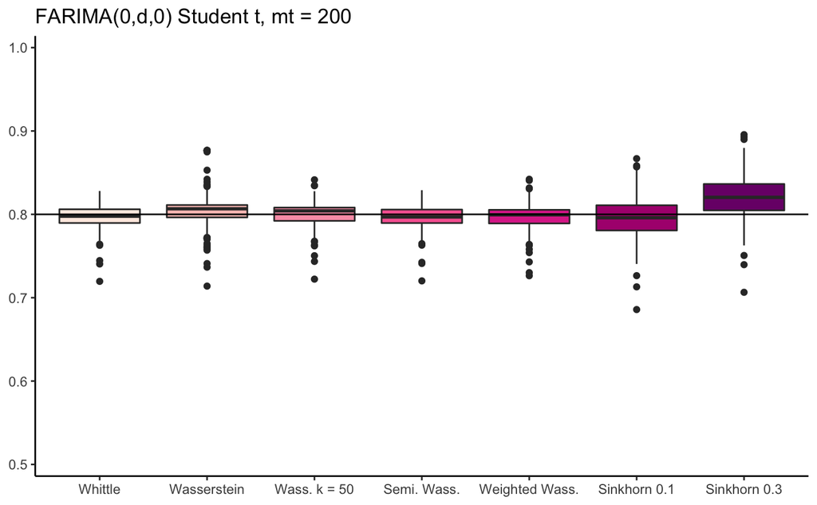

Boxplots of all the estimators presented during this thesis. The sample size of the 200 simulated FARIMA(0,d,0) is 3201 and the underlying distribution is a Student t with degree of freedom equal to 2.

```r
knitr::include_graphics("/Users/manonfelix/OneDrive/Master thesis/Redaction/images/boxplot_farima_student.png")
```

```r
mt = 200

set.seed(1405)


WH_G1 = numeric(mt)
WD_G1 = numeric(mt)
Weighted_WD_G1 = numeric(mt)
WD_cdf_G1 = numeric(mt)
WD_mean_G1 = numeric(mt)
SH_01_G1 = numeric(mt)
SH_03_G1 = numeric(mt)

for (i in 1:mt){
  n = 3201
  H = 0.8
  t = rexp(1600, rate = 1)
  y = fracdiff::fracdiff.sim(n, d = H - 1/2, rand.gen = rt , df = 2)
  y = y$series

  res = optimize(Whittle, lower = 0.51, upper = 0.99, maximum = FALSE, theta = 0, phi = 0, p = 0, q = 0, y = y)
  WH_G1[i] = res$minimum

  res = optimize(Wasserstein, lower = 0.51, upper = 0.99, maximum = FALSE, theta = 0 , phi = 0, p = 0, q = 0, y = y, theoritical = t)
  WD_G1[i] = res$minimum

  res = optimize(Wasserstein, lower = 0.51, upper = 0.99, maximum = FALSE, theta = 0 , phi = 0, p = 0, q = 0, y = y, theoritical = t, mean = TRUE, k = 50)
  WD_mean_G1[i] = res$minimum

  res = optimize(Wasserstein, lower = 0.51, upper = 0.99, maximum = FALSE, theta = 0 , phi = 0, p = 0, q = 0, y = y, theoritical = t, cdf = TRUE)
  WD_cdf_G1[i] = res$minimum

  res = optimize(Wasserstein, lower = 0.51, upper = 0.99, maximum = FALSE, theta = 0 , phi = 0, p = 0, q = 0, y = y, theoritical = t, weighted = TRUE)
  Weighted_WD_G1[i] = res$minimum

  res = optimize(Wasserstein, lower = 0.51, upper = 0.99, maximum = FALSE, theta = 0, phi = 0, p = 0, q = 0, y = y, theoritical = t, weighted = FALSE, sinkhorn = TRUE, lambda = 0.1)
  SH_01_G1[i] = res$minimum

  res = optimize(Wasserstein, lower = 0.51, upper = 0.99, maximum = FALSE, theta = 0, phi = 0, p = 0, q = 0, y = y, theoritical = t, weighted = FALSE, sinkhorn = TRUE, lambda = 0.3)
  SH_03_G1[i] = res$minimum
}
```

```r
a = data.frame(group = "Whittle", value = WH_G1)
b = data.frame(group = "Wasserstein", value = WD_G1)
c = data.frame(group = "Weighted Wass.", value = Weighted_WD_G1)
d = data.frame(group = "Semi. Wass.", value = WD_cdf_G1)
e = data.frame(group = "Wass. k = 50", value = WD_mean_G1)
f = data.frame(group = "Sinkhorn 0.1", value = SH_01_G1)
g = data.frame(group = "Sinkhorn 0.3", value = SH_03_G1)

H = 0.8


plot.data = rbind(a, b, c, d ,e,f,g)


mse = cbind(a, b, c, d, e,f,g)
mse = as.data.frame(mse)


for (i in c(2,4,6,8,10,12,14)){
  MSE = sum((mse[,i] - theta0)^2)
  print(paste(mse[1,i-1], ": Mean Squared Error = ", round(MSE, digits = 5)))
}

plot.data$group = as.factor(plot.data$group)
plot.data$group = factor(plot.data$group, levels = c("Whittle", "Wasserstein", "Wass. k = 50", "Semi. Wass.", "Weighted Wass.", "Sinkhorn 0.1", "Sinkhorn 0.3"))

library(ggplot2)
ggplot(plot.data, aes(x=group, y=Re(value), fill=group)) +
  geom_boxplot()+
  theme_classic() +
  theme(legend.position = "none") +
  geom_hline(yintercept = H) +
  theme(axis.title.x=element_blank()) +
  theme(axis.title.y=element_blank()) +
  ggtitle("FARIMA(0,d,0) Student t, mt = 200")+
  scale_fill_brewer(palette = "RdPu") +
  ylim(0.51, 0.99)
```